# 1. Business Problem

### 4.4.2. Testing model with best hyper parameters

```
Log loss : 1.1507249602637286
Number of mis-classified points : 0.3684210526315789
-------------------- Confusion matrix --------------------
```

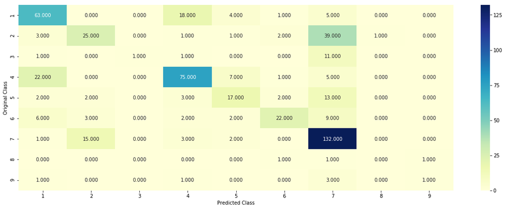

```
-------------------- Precision matrix (Columm Sum=1) --------------------
```

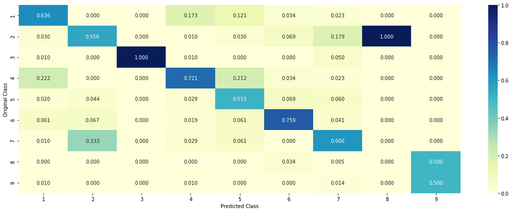

```
-------------------- Recall matrix (Row sum=1) --------------------
```

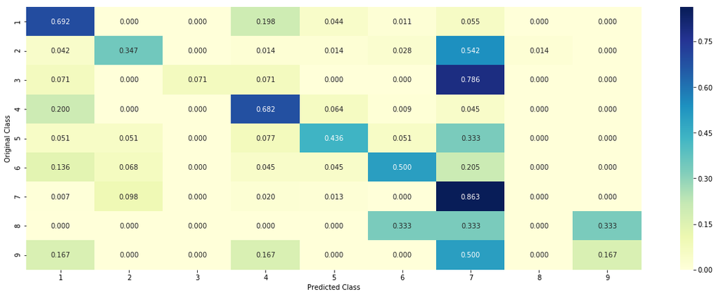

```python
# read more about support vector machines with linear kernals here http://scikit-learn.org/stable/modules/generated/sklearn.svm.SVC.html

# --------------------------------
# default parameters
# SVC(C=1.0, kernel=’rbf’, degree=3, gamma=’auto’, coef0=0.0, shrinking=True, probability=False, tol=0.001,
# cache_size=200, class_weight=None, verbose=False, max_iter=-1, decision_function_shape=’ovr’, random_state=None)

# Some of methods of SVM()
# fit(X, y, [sample_weight])	Fit the SVM model according to the given training data.
# predict(X)	Perform classification on samples in X.
# --------------------------------
# video link: https://www.appliedaicourse.com/course/applied-ai-course-online/lessons/mathematical-derivation-copy-8/
# --------------------------------


# clf = SVC(C=alpha[best_alpha],kernel='linear',probability=True, class_weight='balanced')
clf = SGDClassifier(alpha=alpha[best_alpha], penalty='l2', loss='hinge', random_state=42,class_weight='balanced')
predict_and_plot_confusion_matrix(train_x_onehotCoding, train_y,cv_x_onehotCoding,cv_y, clf)
```

### 4.3.3. Feature Importance

```python
clf = SGDClassifier(alpha=alpha[best_alpha], penalty='l2', loss='hinge', random_state=42)
clf.fit(train_x_onehotCoding,train_y)
test_point_index = 2
# test_point_index = 100
no_feature = 500
predicted_cls = sig_clf.predict(test_x_onehotCoding[test_point_index])
print("Predicted Class :", predicted_cls[0])
print("Predicted Class Probabilities:", np.round(sig_clf.predict_proba(test_x_onehotCoding[test_point_index]),4))
print("Actual Class :", test_y[test_point_index])
indices = np.argsort(-clf.coef_)[predicted_cls-1][:,:no_feature]
print("-"*50)
get_impfeature_names(indices[0], test_df['TEXT'].iloc[test_point_index],test_df['Gene'].iloc[test_point_index],test_df['Variation'].iloc[test_point_index], no_feature)
```

```
Predicted Class : 4
Predicted Class Probabilities: [[0.1787 0.0311 0.013  0.6536 0.0166 0.0741 0.023  0.0035 0.0064]]
Actual Class : 4
--------------------------------------------------
30 Text feature [show] present in test data point [True]
137 Text feature [recognition] present in test data point [True]
138 Text feature [unable] present in test data point [True]
167 Text feature [see] present in test data point [True]
175 Text feature [inactivation] present in test data point [True]
183 Text feature [catalytic] present in test data point [True]
190 Text feature [nature] present in test data point [True]
202 Text feature [purified] present in test data point [True]
206 Text feature [substrate] present in test data point [True]
212 Text feature [high] present in test data point [True]
217 Text feature [rate] present in test data point [True]
```

[output cut: 79 more lines]

```python
test_point_index = 100
no_feature = 500
predicted_cls = sig_clf.predict(test_x_onehotCoding[test_point_index])
print("Predicted Class :", predicted_cls[0])
print("Predicted Class Probabilities:", np.round(sig_clf.predict_proba(test_x_onehotCoding[test_point_index]),4))
print("Actual Class :", test_y[test_point_index])
indices = np.argsort(-clf.coef_)[predicted_cls-1][:,:no_feature]
print("-"*50)
get_impfeature_names(indices[0], test_df['TEXT'].iloc[test_point_index],test_df['Gene'].iloc[test_point_index],test_df['Variation'].iloc[test_point_index], no_feature)
```

```
Predicted Class : 1
Predicted Class Probabilities: [[0.2987 0.0977 0.0363 0.2477 0.0628 0.0527 0.19   0.0084 0.0057]]
Actual Class : 4
--------------------------------------------------
15 Text feature [hydrophobic] present in test data point [True]
23 Text feature [2006] present in test data point [True]
164 Text feature [encoding] present in test data point [True]
165 Text feature [signals] present in test data point [True]
171 Text feature [signal] present in test data point [True]
172 Text feature [affecting] present in test data point [True]
177 Text feature [next] present in test data point [True]
178 Text feature [subjected] present in test data point [True]
180 Text feature [showing] present in test data point [True]
181 Text feature [reduced] present in test data point [True]
184 Text feature [2001] present in test data point [True]
```

[output cut: 112 more lines]

## 4.5 Random Forest Classifier

### 4.5.1. Hyper paramter tuning (With One hot Encoding)

```python
# --------------------------------
# default parameters
# sklearn.ensemble.RandomForestClassifier(n_estimators=10, criterion=’gini’, max_depth=None, min_samples_split=2,
# min_samples_leaf=1, min_weight_fraction_leaf=0.0, max_features=’auto’, max_leaf_nodes=None, min_impurity_decrease=0.0,
# min_impurity_split=None, bootstrap=True, oob_score=False, n_jobs=1, random_state=None, verbose=0, warm_start=False,
# class_weight=None)

# Some of methods of RandomForestClassifier()
# fit(X, y, [sample_weight])	Fit the SVM model according to the given training data.
# predict(X)	Perform classification on samples in X.
# predict_proba (X)	Perform classification on samples in X.

# some of attributes of  RandomForestClassifier()
# feature_importances_ : array of shape = [n_features]
# The feature importances (the higher, the more important the feature).

# --------------------------------
# video link: https://www.appliedaicourse.com/course/applied-ai-course-online/lessons/random-forest-and-their-construction-2/
# --------------------------------


# find more about CalibratedClassifierCV here at http://scikit-learn.org/stable/modules/generated/sklearn.calibration.CalibratedClassifierCV.html
# ----------------------------
# default paramters
# sklearn.calibration.CalibratedClassifierCV(base_estimator=None, method=’sigmoid’, cv=3)
#
# some of the methods of CalibratedClassifierCV()
# fit(X, y[, sample_weight])	Fit the calibrated model
# get_params([deep])	Get parameters for this estimator.
# predict(X)	Predict the target of new samples.
# predict_proba(X)	Posterior probabilities of classification
#-------------------------------------
# video link:
#-------------------------------------

alpha = [100,200,500,1000,2000]
max_depth = [5, 10]
cv_log_error_array = []
for i in alpha:
    for j in max_depth:
        print("for n_estimators =", i,"and max depth = ", j)
        clf = RandomForestClassifier(n_estimators=i, criterion='gini', max_depth=j, random_state=42, n_jobs=-1)
        clf.fit(train_x_onehotCoding, train_y)
        sig_clf = CalibratedClassifierCV(clf, method="sigmoid")
        sig_clf.fit(train_x_onehotCoding, train_y)
        sig_clf_probs = sig_clf.predict_proba(cv_x_onehotCoding)
        cv_log_error_array.append(log_loss(cv_y, sig_clf_probs, labels=clf.classes_, eps=1e-15))
        print("Log Loss :",log_loss(cv_y, sig_clf_probs))

'''fig, ax = plt.subplots()
features = np.dot(np.array(alpha)[:,None],np.array(max_depth)[None]).ravel()
ax.plot(features, cv_log_error_array,c='g')
for i, txt in enumerate(np.round(cv_log_error_array,3)):
    ax.annotate((alpha[int(i/2)],max_depth[int(i%2)],str(txt)), (features[i],cv_log_error_array[i]))
plt.grid()
plt.title("Cross Validation Error for each alpha")
plt.xlabel("Alpha i's")
plt.ylabel("Error measure")
plt.show()
'''

best_alpha = np.argmin(cv_log_error_array)
clf = RandomForestClassifier(n_estimators=alpha[int(best_alpha/2)], criterion='gini', max_depth=max_depth[int(best_alpha%2)], random_state=42, n_jobs=-1)
clf.fit(train_x_onehotCoding, train_y)
sig_clf = CalibratedClassifierCV(clf, method="sigmoid")
sig_clf.fit(train_x_onehotCoding, train_y)

predict_y = sig_clf.predict_proba(train_x_onehotCoding)
print('For values of best estimator = ', alpha[int(best_alpha/2)], "The train log loss is:",log_loss(train_y, predict_y, labels=clf.classes_, eps=1e-15))
predict_y = sig_clf.predict_proba(cv_x_onehotCoding)
print('For values of best estimator = ', alpha[int(best_alpha/2)], "The cross validation log loss is:",log_loss(cv_y, predict_y, labels=clf.classes_, eps=1e-15))
predict_y = sig_clf.predict_proba(test_x_onehotCoding)
print('For values of best estimator = ', alpha[int(best_alpha/2)], "The test log loss is:",log_loss(test_y, predict_y, labels=clf.classes_, eps=1e-15))
```

```
for n_estimators = 100 and max depth =  5
Log Loss : 1.2736833060564123
for n_estimators = 100 and max depth =  10
Log Loss : 1.2866238127242315
for n_estimators = 200 and max depth =  5
Log Loss : 1.2592700584628636
for n_estimators = 200 and max depth =  10
Log Loss : 1.2821426493553543
for n_estimators = 500 and max depth =  5
Log Loss : 1.254971842261894
for n_estimators = 500 and max depth =  10
Log Loss : 1.2749355432584017
for n_estimators = 1000 and max depth =  5
Log Loss : 1.2541087998919056
for n_estimators = 1000 and max depth =  10
Log Loss : 1.2708825529942867
for n_estimators = 2000 and max depth =  5
Log Loss : 1.2530043674412312
for n_estimators = 2000 and max depth =  10
Log Loss : 1.2713692573094837
For values of best estimator =  2000 The train log loss is: 0.8373793153262201
For values of best estimator =  2000 The cross validation log loss is: 1.2530043674412312
For values of best estimator =  2000 The test log loss is: 1.2287422809963742
```

### 4.5.2. Testing model with best hyper parameters (One Hot Encoding)

```
Log loss : 1.2530043674412312
Number of mis-classified points : 0.4774436090225564
-------------------- Confusion matrix --------------------
```

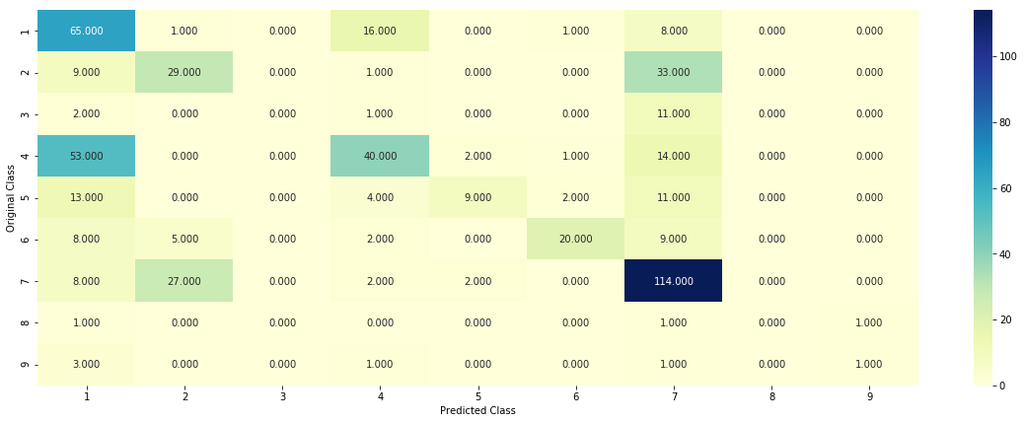

```
-------------------- Precision matrix (Columm Sum=1) --------------------
```

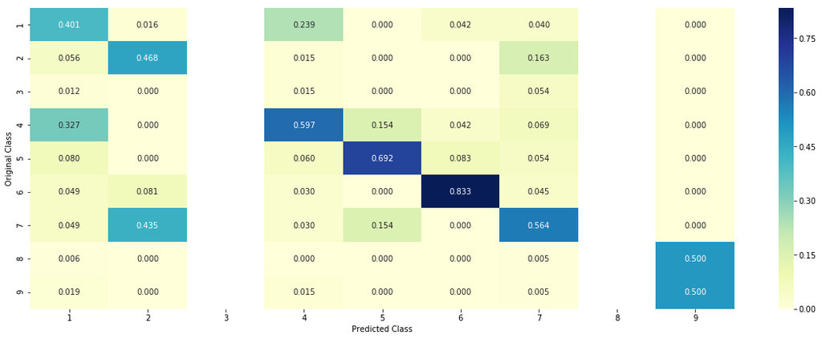

```
-------------------- Recall matrix (Row sum=1) --------------------
```

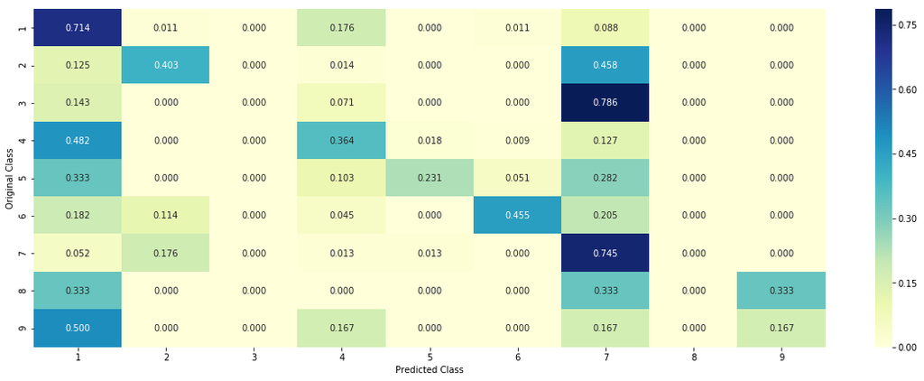

```python
# --------------------------------
# default parameters
# sklearn.ensemble.RandomForestClassifier(n_estimators=10, criterion=’gini’, max_depth=None, min_samples_split=2,
# min_samples_leaf=1, min_weight_fraction_leaf=0.0, max_features=’auto’, max_leaf_nodes=None, min_impurity_decrease=0.0,
# min_impurity_split=None, bootstrap=True, oob_score=False, n_jobs=1, random_state=None, verbose=0, warm_start=False,
# class_weight=None)

# Some of methods of RandomForestClassifier()
# fit(X, y, [sample_weight])	Fit the SVM model according to the given training data.
# predict(X)	Perform classification on samples in X.
# predict_proba (X)	Perform classification on samples in X.

# some of attributes of  RandomForestClassifier()
# feature_importances_ : array of shape = [n_features]
# The feature importances (the higher, the more important the feature).

# --------------------------------
# video link: https://www.appliedaicourse.com/course/applied-ai-course-online/lessons/random-forest-and-their-construction-2/
# --------------------------------

clf = RandomForestClassifier(n_estimators=alpha[int(best_alpha/2)], criterion='gini', max_depth=max_depth[int(best_alpha%2)], random_state=42, n_jobs=-1)
predict_and_plot_confusion_matrix(train_x_onehotCoding, train_y,cv_x_onehotCoding,cv_y, clf)
```

### 4.5.3. Feature Importance

#### 4.5.3.1. Correctly Classified point

```python
# test_point_index = 10
clf = RandomForestClassifier(n_estimators=alpha[int(best_alpha/2)], criterion='gini', max_depth=max_depth[int(best_alpha%2)], random_state=42, n_jobs=-1)
clf.fit(train_x_onehotCoding, train_y)
sig_clf = CalibratedClassifierCV(clf, method="sigmoid")
sig_clf.fit(train_x_onehotCoding, train_y)

test_point_index = 2
no_feature = 100
predicted_cls = sig_clf.predict(test_x_onehotCoding[test_point_index])
print("Predicted Class :", predicted_cls[0])
print("Predicted Class Probabilities:", np.round(sig_clf.predict_proba(test_x_onehotCoding[test_point_index]),4))
print("Actual Class :", test_y[test_point_index])
indices = np.argsort(-clf.feature_importances_)
print("-"*50)
get_impfeature_names(indices[:no_feature], test_df['TEXT'].iloc[test_point_index],test_df['Gene'].iloc[test_point_index],test_df['Variation'].iloc[test_point_index], no_feature)
```

```
Predicted Class : 4
Predicted Class Probabilities: [[0.2666 0.0639 0.0185 0.4108 0.0728 0.0855 0.0551 0.0098 0.017 ]]
Actual Class : 4
--------------------------------------------------
4 Text feature [function] present in test data point [True]
5 Text feature [inhibitors] present in test data point [True]
9 Text feature [inhibitor] present in test data point [True]
19 Text feature [treated] present in test data point [True]
22 Text feature [expression] present in test data point [True]
23 Text feature [protein] present in test data point [True]
28 Text feature [neutral] present in test data point [True]
40 Text feature [therapeutic] present in test data point [True]
42 Text feature [yeast] present in test data point [True]
56 Text feature [inhibition] present in test data point [True]
62 Text feature [resistance] present in test data point [True]
66 Text feature [drug] present in test data point [True]
70 Text feature [predicted] present in test data point [True]
72 Text feature [downstream] present in test data point [True]
74 Text feature [inactivation] present in test data point [True]
84 Text feature [sensitive] present in test data point [True]
86 Text feature [assays] present in test data point [True]
94 Text feature [information] present in test data point [True]
99 Text feature [sequence] present in test data point [True]
Out of the top  100  features  19 are present in query point
```

```python
test_point_index = 1
no_feature = 100
predicted_cls = sig_clf.predict(test_x_onehotCoding[test_point_index])
print("Predicted Class :", predicted_cls[0])
print("Predicted Class Probabilities:", np.round(sig_clf.predict_proba(test_x_onehotCoding[test_point_index]),4))
print("Actuall Class :", test_y[test_point_index])
indices = np.argsort(-clf.feature_importances_)
print("-"*50)
get_impfeature_names(indices[:no_feature], test_df['TEXT'].iloc[test_point_index],test_df['Gene'].iloc[test_point_index],test_df['Variation'].iloc[test_point_index], no_feature)
```

```
Predicted Class : 1
Predicted Class Probabilities: [[0.4615 0.009  0.0121 0.0884 0.2802 0.1297 0.0144 0.0035 0.0012]]
Actuall Class : 1
--------------------------------------------------
0 Text feature [kinase] present in test data point [True]
1 Text feature [activating] present in test data point [True]
4 Text feature [function] present in test data point [True]
6 Text feature [activation] present in test data point [True]
7 Text feature [suppressor] present in test data point [True]
8 Text feature [phosphorylation] present in test data point [True]
10 Text feature [loss] present in test data point [True]
11 Text feature [missense] present in test data point [True]
13 Text feature [brca1] present in test data point [True]
14 Text feature [constitutive] present in test data point [True]
16 Text feature [deleterious] present in test data point [True]
```

[output cut: 44 more lines]

### 4.5.3. Hyper paramter tuning (With Response Coding)

```python
# --------------------------------
# default parameters
# sklearn.ensemble.RandomForestClassifier(n_estimators=10, criterion=’gini’, max_depth=None, min_samples_split=2,
# min_samples_leaf=1, min_weight_fraction_leaf=0.0, max_features=’auto’, max_leaf_nodes=None, min_impurity_decrease=0.0,
# min_impurity_split=None, bootstrap=True, oob_score=False, n_jobs=1, random_state=None, verbose=0, warm_start=False,
# class_weight=None)

# Some of methods of RandomForestClassifier()
# fit(X, y, [sample_weight])	Fit the SVM model according to the given training data.
# predict(X)	Perform classification on samples in X.
# predict_proba (X)	Perform classification on samples in X.

# some of attributes of  RandomForestClassifier()
# feature_importances_ : array of shape = [n_features]
# The feature importances (the higher, the more important the feature).

# --------------------------------
# video link: https://www.appliedaicourse.com/course/applied-ai-course-online/lessons/random-forest-and-their-construction-2/
# --------------------------------


# find more about CalibratedClassifierCV here at http://scikit-learn.org/stable/modules/generated/sklearn.calibration.CalibratedClassifierCV.html
# ----------------------------
# default paramters
# sklearn.calibration.CalibratedClassifierCV(base_estimator=None, method=’sigmoid’, cv=3)
#
# some of the methods of CalibratedClassifierCV()
# fit(X, y[, sample_weight])	Fit the calibrated model
# get_params([deep])	Get parameters for this estimator.
# predict(X)	Predict the target of new samples.
# predict_proba(X)	Posterior probabilities of classification
#-------------------------------------
# video link:
#-------------------------------------

alpha = [10,50,100,200,500,1000]
max_depth = [2,3,5,10]
cv_log_error_array = []
for i in alpha:
    for j in max_depth:
        print("for n_estimators =", i,"and max depth = ", j)
        clf = RandomForestClassifier(n_estimators=i, criterion='gini', max_depth=j, random_state=42, n_jobs=-1)
        clf.fit(train_x_responseCoding, train_y)
        sig_clf = CalibratedClassifierCV(clf, method="sigmoid")
        sig_clf.fit(train_x_responseCoding, train_y)
        sig_clf_probs = sig_clf.predict_proba(cv_x_responseCoding)
        cv_log_error_array.append(log_loss(cv_y, sig_clf_probs, labels=clf.classes_, eps=1e-15))
        print("Log Loss :",log_loss(cv_y, sig_clf_probs))
'''
fig, ax = plt.subplots()
features = np.dot(np.array(alpha)[:,None],np.array(max_depth)[None]).ravel()
ax.plot(features, cv_log_error_array,c='g')
for i, txt in enumerate(np.round(cv_log_error_array,3)):
    ax.annotate((alpha[int(i/4)],max_depth[int(i%4)],str(txt)), (features[i],cv_log_error_array[i]))
plt.grid()
plt.title("Cross Validation Error for each alpha")
plt.xlabel("Alpha i's")
plt.ylabel("Error measure")
plt.show()
'''

best_alpha = np.argmin(cv_log_error_array)
clf = RandomForestClassifier(n_estimators=alpha[int(best_alpha/4)], criterion='gini', max_depth=max_depth[int(best_alpha%4)], random_state=42, n_jobs=-1)
clf.fit(train_x_responseCoding, train_y)
sig_clf = CalibratedClassifierCV(clf, method="sigmoid")
sig_clf.fit(train_x_responseCoding, train_y)

predict_y = sig_clf.predict_proba(train_x_responseCoding)
print('For values of best alpha = ', alpha[int(best_alpha/4)], "The train log loss is:",log_loss(train_y, predict_y, labels=clf.classes_, eps=1e-15))
predict_y = sig_clf.predict_proba(cv_x_responseCoding)
print('For values of best alpha = ', alpha[int(best_alpha/4)], "The cross validation log loss is:",log_loss(cv_y, predict_y, labels=clf.classes_, eps=1e-15))
predict_y = sig_clf.predict_proba(test_x_responseCoding)
print('For values of best alpha = ', alpha[int(best_alpha/4)], "The test log loss is:",log_loss(test_y, predict_y, labels=clf.classes_, eps=1e-15))
```

```
for n_estimators = 10 and max depth =  2
Log Loss : 2.079365058178695
for n_estimators = 10 and max depth =  3
Log Loss : 1.8462568629847556
for n_estimators = 10 and max depth =  5
Log Loss : 1.6096718798690968
for n_estimators = 10 and max depth =  10
Log Loss : 1.7633623284047186
for n_estimators = 50 and max depth =  2
Log Loss : 1.7622098557578474
for n_estimators = 50 and max depth =  3
Log Loss : 1.4779538115449786
for n_estimators = 50 and max depth =  5
Log Loss : 1.4371067464371061
for n_estimators = 50 and max depth =  10
Log Loss : 1.602248688059107
for n_estimators = 100 and max depth =  2
Log Loss : 1.651866558136504
for n_estimators = 100 and max depth =  3
Log Loss : 1.4815840784491068
for n_estimators = 100 and max depth =  5
Log Loss : 1.3487282040932687
for n_estimators = 100 and max depth =  10
Log Loss : 1.6375837824221184
for n_estimators = 200 and max depth =  2
Log Loss : 1.677717997094418
for n_estimators = 200 and max depth =  3
Log Loss : 1.512448759049706
for n_estimators = 200 and max depth =  5
Log Loss : 1.3675126372326867
for n_estimators = 200 and max depth =  10
Log Loss : 1.630680588040141
for n_estimators = 500 and max depth =  2
Log Loss : 1.6747384716800862
for n_estimators = 500 and max depth =  3
Log Loss : 1.5379303963159887
for n_estimators = 500 and max depth =  5
Log Loss : 1.3884965770944975
for n_estimators = 500 and max depth =  10
Log Loss : 1.661659826257498
for n_estimators = 1000 and max depth =  2
Log Loss : 1.6825821016824942
for n_estimators = 1000 and max depth =  3
Log Loss : 1.5668780450451543
for n_estimators = 1000 and max depth =  5
Log Loss : 1.3567924320714277
for n_estimators = 1000 and max depth =  10
Log Loss : 1.6604394899738006
For values of best alpha =  100 The train log loss is: 0.058311217812717565
For values of best alpha =  100 The cross validation log loss is: 1.3487282040932687
For values of best alpha =  100 The test log loss is: 1.3145360187535424
```

### 4.5.4. Testing model with best hyper parameters (Response Coding)

```
Log loss : 1.348728204093269
Number of mis-classified points : 0.43796992481203006
-------------------- Confusion matrix --------------------
```

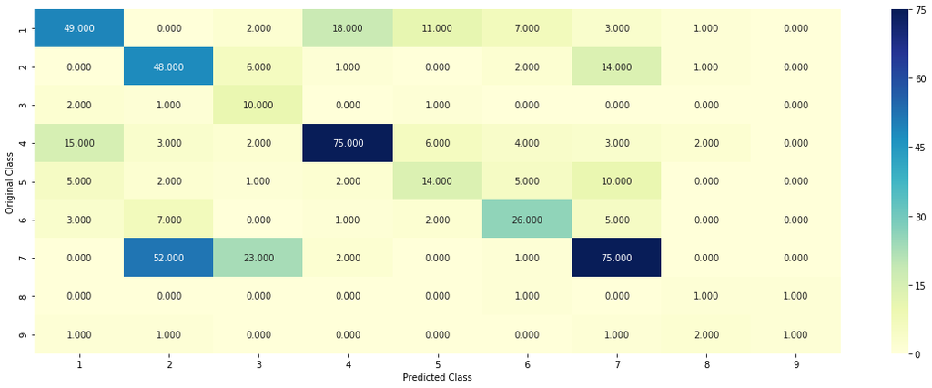

```
-------------------- Precision matrix (Columm Sum=1) --------------------
```

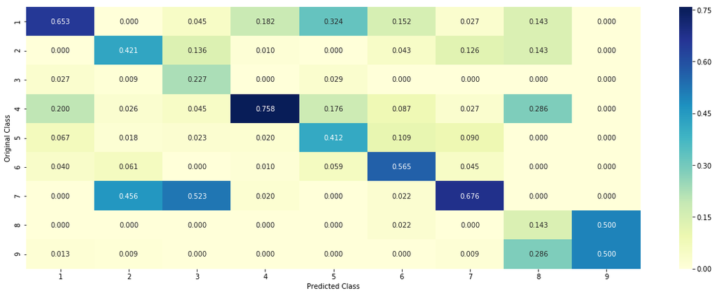

```
-------------------- Recall matrix (Row sum=1) --------------------
```

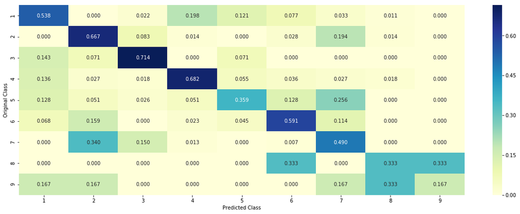

```python
# --------------------------------
# default parameters
# sklearn.ensemble.RandomForestClassifier(n_estimators=10, criterion=’gini’, max_depth=None, min_samples_split=2,
# min_samples_leaf=1, min_weight_fraction_leaf=0.0, max_features=’auto’, max_leaf_nodes=None, min_impurity_decrease=0.0,
# min_impurity_split=None, bootstrap=True, oob_score=False, n_jobs=1, random_state=None, verbose=0, warm_start=False,
# class_weight=None)

# Some of methods of RandomForestClassifier()
# fit(X, y, [sample_weight])	Fit the SVM model according to the given training data.
# predict(X)	Perform classification on samples in X.
# predict_proba (X)	Perform classification on samples in X.

# some of attributes of  RandomForestClassifier()
# feature_importances_ : array of shape = [n_features]
# The feature importances (the higher, the more important the feature).

# --------------------------------
# video link: https://www.appliedaicourse.com/course/applied-ai-course-online/lessons/random-forest-and-their-construction-2/
# --------------------------------

clf = RandomForestClassifier(max_depth=max_depth[int(best_alpha%4)], n_estimators=alpha[int(best_alpha/4)], criterion='gini', max_features='auto',random_state=42)
predict_and_plot_confusion_matrix(train_x_responseCoding, train_y,cv_x_responseCoding,cv_y, clf)
```

### 4.5.5. Feature Importance

```python
clf = RandomForestClassifier(n_estimators=alpha[int(best_alpha/4)], criterion='gini', max_depth=max_depth[int(best_alpha%4)], random_state=42, n_jobs=-1)
clf.fit(train_x_responseCoding, train_y)
sig_clf = CalibratedClassifierCV(clf, method="sigmoid")
sig_clf.fit(train_x_responseCoding, train_y)


test_point_index = 1
no_feature = 27
predicted_cls = sig_clf.predict(test_x_responseCoding[test_point_index].reshape(1,-1))
print("Predicted Class :", predicted_cls[0])
print("Predicted Class Probabilities:", np.round(sig_clf.predict_proba(test_x_responseCoding[test_point_index].reshape(1,-1)),4))
print("Actual Class :", test_y[test_point_index])
indices = np.argsort(-clf.feature_importances_)
print("-"*50)
for i in indices:
    if i<9:
        print("Gene is important feature")
    elif i<18:
        print("Variation is important feature")
    else:
        print("Text is important feature")
```

```
Predicted Class : 5
Predicted Class Probabilities: [[0.036  0.0049 0.0735 0.0357 0.6898 0.1486 0.0033 0.0042 0.004 ]]
Actual Class : 1
--------------------------------------------------
Variation is important feature
Variation is important feature
Variation is important feature
Variation is important feature
Gene is important feature
Variation is important feature
Variation is important feature
Text is important feature
Gene is important feature
Text is important feature
Text is important feature
Text is important feature
Text is important feature
Gene is important feature
Gene is important feature
Variation is important feature
Gene is important feature
Gene is important feature
Text is important feature
Variation is important feature
Text is important feature
Text is important feature
Text is important feature
Variation is important feature
Gene is important feature
Gene is important feature
Gene is important feature
```

```python
test_point_index = 2
predicted_cls = sig_clf.predict(test_x_responseCoding[test_point_index].reshape(1,-1))
print("Predicted Class :", predicted_cls[0])
print("Predicted Class Probabilities:", np.round(sig_clf.predict_proba(test_x_responseCoding[test_point_index].reshape(1,-1)),4))
print("Actual Class :", test_y[test_point_index])
indices = np.argsort(-clf.feature_importances_)
print("-"*50)
for i in indices:
    if i<9:
        print("Gene is important feature")
    elif i<18:
        print("Variation is important feature")
    else:
        print("Text is important feature")
```

```
Predicted Class : 4
Predicted Class Probabilities: [[0.1246 0.0395 0.146  0.5226 0.0199 0.0673 0.0176 0.0428 0.0195]]
Actual Class : 4
--------------------------------------------------
Variation is important feature
Variation is important feature
Variation is important feature
Variation is important feature
Gene is important feature
Variation is important feature
Variation is important feature
Text is important feature
Gene is important feature
Text is important feature
Text is important feature
Text is important feature
Text is important feature
Gene is important feature
Gene is important feature
Variation is important feature
Gene is important feature
Gene is important feature
Text is important feature
Variation is important feature
Text is important feature
Text is important feature
Text is important feature
Variation is important feature
Gene is important feature
Gene is important feature
Gene is important feature
```

## 4.7 Stack the models

### 4.7.1 testing with hyper parameter tuning

```python
# read more about SGDClassifier() at http://scikit-learn.org/stable/modules/generated/sklearn.linear_model.SGDClassifier.html
# ------------------------------
# default parameters
# SGDClassifier(loss=’hinge’, penalty=’l2’, alpha=0.0001, l1_ratio=0.15, fit_intercept=True, max_iter=None, tol=None,
# shuffle=True, verbose=0, epsilon=0.1, n_jobs=1, random_state=None, learning_rate=’optimal’, eta0=0.0, power_t=0.5,
# class_weight=None, warm_start=False, average=False, n_iter=None)

# some of methods
# fit(X, y[, coef_init, intercept_init, …])	Fit linear model with Stochastic Gradient Descent.
# predict(X)	Predict class labels for samples in X.

#-------------------------------
# video link: https://www.appliedaicourse.com/course/applied-ai-course-online/lessons/geometric-intuition-1/
#------------------------------


# read more about support vector machines with linear kernals here http://scikit-learn.org/stable/modules/generated/sklearn.svm.SVC.html
# --------------------------------
# default parameters
# SVC(C=1.0, kernel=’rbf’, degree=3, gamma=’auto’, coef0=0.0, shrinking=True, probability=False, tol=0.001,
# cache_size=200, class_weight=None, verbose=False, max_iter=-1, decision_function_shape=’ovr’, random_state=None)

# Some of methods of SVM()
# fit(X, y, [sample_weight])	Fit the SVM model according to the given training data.
# predict(X)	Perform classification on samples in X.
# --------------------------------
# video link: https://www.appliedaicourse.com/course/applied-ai-course-online/lessons/mathematical-derivation-copy-8/
# --------------------------------


# read more about support vector machines with linear kernals here http://scikit-learn.org/stable/modules/generated/sklearn.ensemble.RandomForestClassifier.html
# --------------------------------
# default parameters
# sklearn.ensemble.RandomForestClassifier(n_estimators=10, criterion=’gini’, max_depth=None, min_samples_split=2,
# min_samples_leaf=1, min_weight_fraction_leaf=0.0, max_features=’auto’, max_leaf_nodes=None, min_impurity_decrease=0.0,
# min_impurity_split=None, bootstrap=True, oob_score=False, n_jobs=1, random_state=None, verbose=0, warm_start=False,
# class_weight=None)

# Some of methods of RandomForestClassifier()
# fit(X, y, [sample_weight])	Fit the SVM model according to the given training data.
# predict(X)	Perform classification on samples in X.
# predict_proba (X)	Perform classification on samples in X.

# some of attributes of  RandomForestClassifier()
# feature_importances_ : array of shape = [n_features]
# The feature importances (the higher, the more important the feature).

# --------------------------------
# video link: https://www.appliedaicourse.com/course/applied-ai-course-online/lessons/random-forest-and-their-construction-2/
# --------------------------------


clf1 = SGDClassifier(alpha=0.001, penalty='l2', loss='log', class_weight='balanced', random_state=0)
clf1.fit(train_x_onehotCoding, train_y)
sig_clf1 = CalibratedClassifierCV(clf1, method="sigmoid")

clf2 = SGDClassifier(alpha=1, penalty='l2', loss='hinge', class_weight='balanced', random_state=0)
clf2.fit(train_x_onehotCoding, train_y)
sig_clf2 = CalibratedClassifierCV(clf2, method="sigmoid")


clf3 = MultinomialNB(alpha=0.001)
clf3.fit(train_x_onehotCoding, train_y)
sig_clf3 = CalibratedClassifierCV(clf3, method="sigmoid")

sig_clf1.fit(train_x_onehotCoding, train_y)
print("Logistic Regression :  Log Loss: %0.2f" % (log_loss(cv_y, sig_clf1.predict_proba(cv_x_onehotCoding))))
sig_clf2.fit(train_x_onehotCoding, train_y)
print("Support vector machines : Log Loss: %0.2f" % (log_loss(cv_y, sig_clf2.predict_proba(cv_x_onehotCoding))))
sig_clf3.fit(train_x_onehotCoding, train_y)
print("Naive Bayes : Log Loss: %0.2f" % (log_loss(cv_y, sig_clf3.predict_proba(cv_x_onehotCoding))))
print("-"*50)
alpha = [0.0001,0.001,0.01,0.1,1,10]
best_alpha = 999
for i in alpha:
    lr = LogisticRegression(C=i)
    sclf = StackingClassifier(classifiers=[sig_clf1, sig_clf2, sig_clf3], meta_classifier=lr, use_probas=True)
    sclf.fit(train_x_onehotCoding, train_y)
    print("Stacking Classifer : for the value of alpha: %f Log Loss: %0.3f" % (i, log_loss(cv_y, sclf.predict_proba(cv_x_onehotCoding))))
    log_error =log_loss(cv_y, sclf.predict_proba(cv_x_onehotCoding))
    if best_alpha > log_error:
        best_alpha = log_error
```

```
Logistic Regression :  Log Loss: 1.10
Support vector machines : Log Loss: 1.87
Naive Bayes : Log Loss: 1.28
--------------------------------------------------
Stacking Classifer : for the value of alpha: 0.000100 Log Loss: 2.178
Stacking Classifer : for the value of alpha: 0.001000 Log Loss: 2.039
Stacking Classifer : for the value of alpha: 0.010000 Log Loss: 1.539
Stacking Classifer : for the value of alpha: 0.100000 Log Loss: 1.223
Stacking Classifer : for the value of alpha: 1.000000 Log Loss: 1.290
Stacking Classifer : for the value of alpha: 10.000000 Log Loss: 1.432
```

### 4.7.2 testing the model with the best hyper parameters

```
Log loss (train) on the stacking classifier : 0.788983916559872
Log loss (CV) on the stacking classifier : 1.2233851026771143
Log loss (test) on the stacking classifier : 1.1894744759046902
Number of missclassified point : 0.40601503759398494
-------------------- Confusion matrix --------------------
```

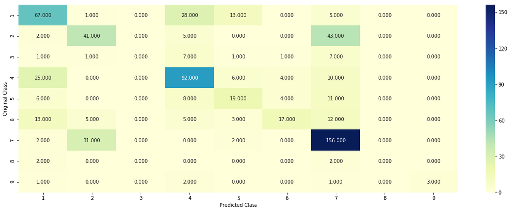

```
-------------------- Precision matrix (Columm Sum=1) --------------------
```

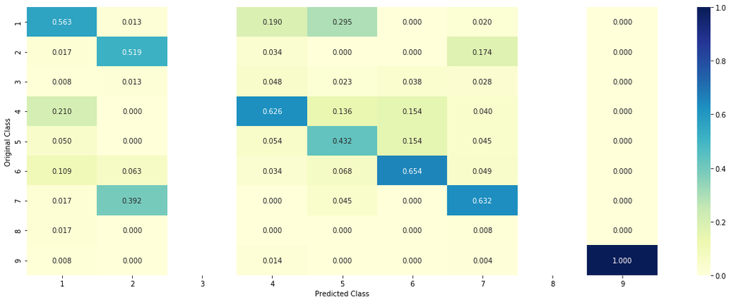

```
-------------------- Recall matrix (Row sum=1) --------------------
```

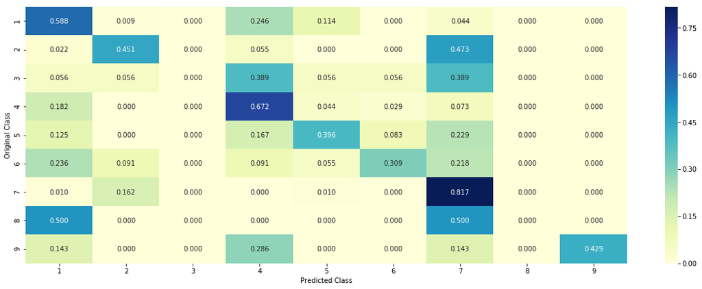

```python
lr = LogisticRegression(C=0.1)
sclf = StackingClassifier(classifiers=[sig_clf1, sig_clf2, sig_clf3], meta_classifier=lr, use_probas=True)
sclf.fit(train_x_onehotCoding, train_y)

log_error = log_loss(train_y, sclf.predict_proba(train_x_onehotCoding))
print("Log loss (train) on the stacking classifier :",log_error)

log_error = log_loss(cv_y, sclf.predict_proba(cv_x_onehotCoding))
print("Log loss (CV) on the stacking classifier :",log_error)

log_error = log_loss(test_y, sclf.predict_proba(test_x_onehotCoding))
print("Log loss (test) on the stacking classifier :",log_error)

print("Number of missclassified point :", np.count_nonzero((sclf.predict(test_x_onehotCoding)- test_y))/test_y.shape[0])
plot_confusion_matrix(test_y=test_y, predict_y=sclf.predict(test_x_onehotCoding))
```

### 4.7.3 Maximum Voting classifier

```
Log loss (train) on the VotingClassifier : 0.928872836710069
Log loss (CV) on the VotingClassifier : 1.26266597039127
Log loss (test) on the VotingClassifier : 1.2180427822758082
Number of missclassified point : 0.40902255639097745
-------------------- Confusion matrix --------------------
```

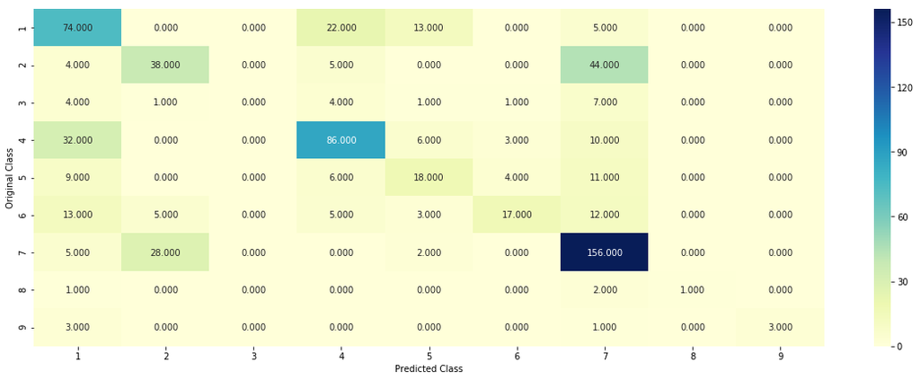

```
-------------------- Precision matrix (Columm Sum=1) --------------------
```

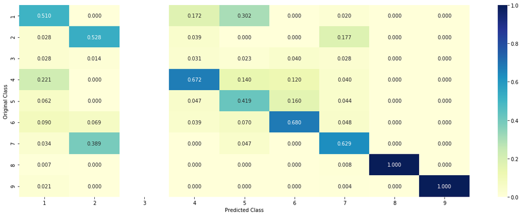

```
-------------------- Recall matrix (Row sum=1) --------------------
```

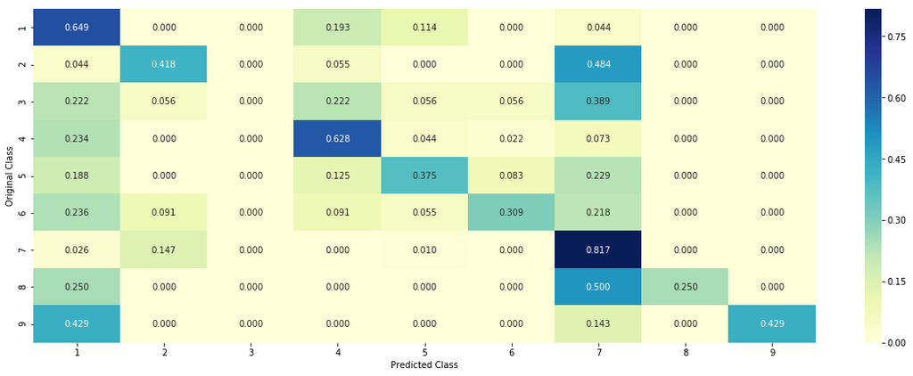

```python
#Refer:http://scikit-learn.org/stable/modules/generated/sklearn.ensemble.VotingClassifier.html
from sklearn.ensemble import VotingClassifier
vclf = VotingClassifier(estimators=[('lr', sig_clf1), ('svc', sig_clf2), ('rf', sig_clf3)], voting='soft')
vclf.fit(train_x_onehotCoding, train_y)
print("Log loss (train) on the VotingClassifier :", log_loss(train_y, vclf.predict_proba(train_x_onehotCoding)))
print("Log loss (CV) on the VotingClassifier :", log_loss(cv_y, vclf.predict_proba(cv_x_onehotCoding)))
print("Log loss (test) on the VotingClassifier :", log_loss(test_y, vclf.predict_proba(test_x_onehotCoding)))
print("Number of missclassified point :", np.count_nonzero((vclf.predict(test_x_onehotCoding)- test_y))/test_y.shape[0])
plot_confusion_matrix(test_y=test_y, predict_y=vclf.predict(test_x_onehotCoding))
```

# 5. Assignments

1. Apply All the models with tf-idf features (Replace CountVectorizer with tfidfVectorizer and run the same cells)
2. Instead of using all the words in the dataset, use only the top 1000 words based of tf-idf values
3. Apply Logistic regression with CountVectorizer Features, including both unigrams and bigrams
4. Try any of the feature engineering techniques discussed in the course to reduce the CV and test log-loss to a value less than 1.0

## Logistic regression with CountVectorizer Features, including both unigrams and bigrams

```python
print(train_df.shape, y_train.shape)
print(cv_df.shape, y_cv.shape)
print(test_df.shape, y_test.shape)
```

```
(2124, 5) (2124,)
(532, 5) (532,)
(665, 5) (665,)
```

```python
train_df.head()
```

|  | ID | Gene | Variation | Class | TEXT |
| --- | --- | --- | --- | --- | --- |
| 1076 | 1076 | FOXA1 | F400I | 1 | characterization prostate cancer transcriptome... |
| 283 | 283 | NKX2-1 | TRA-NKX2-1_Fusion | 2 | 40 pediatric cases underlying oncogenic rearra... |
| 2125 | 2125 | CCND1 | T286I | 7 | activities cyclin dependent kinases serve inte... |
| 962 | 962 | ESR1 | Fusions | 2 | crucial role recurrent gene fusions developmen... |
| 1278 | 1278 | HRAS | G12V | 7 | three dimensional structure complex human h ra... |

```python
# Feature : Gene

#Apply Count Vectorizer that includes both unigram and bigram
count_vect = CountVectorizer(ngram_range=(1, 2))
train_gene_feature_onehotCoding = count_vect.fit_transform(train_df['Gene'])
test_gene_feature_onehotCoding = count_vect.transform(test_df['Gene'])
cv_gene_feature_onehotCoding = count_vect.transform(cv_df['Gene'])

# Normalize the gene feature vectors
# train_gene_feature_onehotCoding = normalize(train_gene_feature_onehotCoding, axis = 0)
# test_gene_feature_onehotCoding = normalize(test_gene_feature_onehotCoding, axis = 0)
# cv_gene_feature_onehotCoding = normalize(cv_gene_feature_onehotCoding, axis = 0)

# Feature : Variation
train_variation_feature_onehotCoding = count_vect.fit_transform(train_df['Variation'])
test_variation_feature_onehotCoding = count_vect.transform(test_df['Variation'])
cv_variation_feature_onehotCoding = count_vect.transform(cv_df['Variation'])

# normalize the Variation feature vectors
# train_variation_feature_onehotCoding = normalize(train_variation_feature_onehotCoding, axis = 0)
# test_variation_feature_onehotCoding = normalize(test_variation_feature_onehotCoding, axis = 0)
# cv_variation_feature_onehotCoding = normalize(cv_variation_feature_onehotCoding, axis = 0)
```

```python
# Feature : TEXT
# building a CountVectorizer with all the words that occured minimum 3 times in train data

count_vect = CountVectorizer(ngram_range=(1, 2), min_df=3)
train_text_feature_onehotCoding = count_vect.fit_transform(train_df['TEXT'])
# train_text_feature_onehotCoding = normalize(train_text_feature_onehotCoding, axis=0)
test_text_feature_onehotCoding = count_vect.transform(test_df['TEXT'])
# test_text_feature_onehotCoding = normalize(test_text_feature_onehotCoding, axis=0)
cv_text_feature_onehotCoding = count_vect.transform(cv_df['TEXT'])
# cv_text_feature_onehotCoding = normalize(cv_text_feature_onehotCoding, axis=0)
```

```python
train_gene_var_onehotCoding = hstack((train_gene_feature_onehotCoding,train_variation_feature_onehotCoding))
test_gene_var_onehotCoding = hstack((test_gene_feature_onehotCoding,test_variation_feature_onehotCoding))
cv_gene_var_onehotCoding = hstack((cv_gene_feature_onehotCoding,cv_variation_feature_onehotCoding))

train_x_onehotCoding = hstack((train_gene_var_onehotCoding, train_text_feature_onehotCoding)).tocsr()
y_train = train_df['Class']

test_x_onehotCoding = hstack((test_gene_var_onehotCoding, test_text_feature_onehotCoding)).tocsr()
y_test = test_df['Class']

cv_x_onehotCoding = hstack((cv_gene_var_onehotCoding, cv_text_feature_onehotCoding)).tocsr()
y_cv = cv_df['Class']
```

```python
print(train_x_onehotCoding.shape, y_train.shape)
print(cv_x_onehotCoding.shape, y_cv.shape)
print(test_x_onehotCoding.shape, y_test.shape)
```

```
(2124, 773730) (2124,)
(532, 773730) (532,)
(665, 773730) (665,)
```

```
for alpha =  1e-06 The log loss is  1.8304997567764278
for alpha =  1e-05 The log loss is  1.8304997567764278
for alpha =  0.0001 The log loss is  1.8304997567764278
for alpha =  0.001 The log loss is  1.3675245788047465
for alpha =  0.01 The log loss is  1.3029895662623745
for alpha =  0.1 The log loss is  1.2921713185245127
for alpha =  1 The log loss is  1.2282032632077804
for alpha =  10 The log loss is  1.2139672769072973
for alpha =  100 The log loss is  1.3526205023298254
```

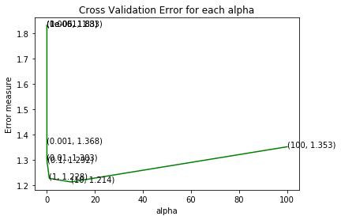

```
For the value alpha :  10 The train log loss is  1.0818267506696408
For the value alpha :  10 The CV log loss is  1.380650468959619
For the value alpha :  10 The test log loss is  1.3463612388642923
```

```python
# Train the model using Logistics Regression and Calibration model

alpha = [10**x for x in range(-6,3)]

cv_log_loss_values = []
for i in alpha:
    clf = SGDClassifier(class_weight = "balanced",alpha = i, loss = 'log', penalty = 'l2', random_state = 42)
    clf.fit(train_x_onehotCoding, y_train)
    sig_clf = CalibratedClassifierCV(clf,method = 'sigmoid')
    sig_clf.fit(train_x_onehotCoding, y_train)
    predict_y = sig_clf.predict_proba(cv_x_onehotCoding)
#     log_loss = log_loss(y_cv, predict_y,labels=clf.classes_, eps=1e-15)
    cv_log_loss_values.append(log_loss(y_cv, predict_y,labels=clf.classes_, eps=1e-15))
    print("for alpha = ", i, "The log loss is ", log_loss(y_cv, predict_y,labels=clf.classes_, eps=1e-15))

plt.plot(alpha, cv_log_loss_values, c = 'g')
for i, txt in enumerate(np.round(cv_log_loss_values,3)):
    plt.annotate((alpha[i],txt),(alpha[i],cv_log_loss_values[i]))

plt.title('Cross Validation Error for each alpha')
plt.xlabel('alpha')
plt.ylabel('Error measure')
plt.show()

optimal_alpha = alpha[np.argmin(cv_log_loss_values)]

clf = SGDClassifier(class_weight = "balanced",alpha = optimal_alpha, loss = 'log', penalty = 'l2', random_state = 42)
clf.fit(train_x_onehotCoding, y_train)
sig_clf = CalibratedClassifierCV(method = 'sigmoid')
sig_clf.fit(train_x_onehotCoding, y_train)

predict_y = sig_clf.predict_proba(train_x_onehotCoding)
print("For the value alpha : ", optimal_alpha, "The train log loss is ", log_loss(y_train, predict_y))
predict_y = sig_clf.predict_proba(cv_x_onehotCoding)
print("For the value alpha : ", optimal_alpha, "The CV log loss is ",log_loss(y_cv, predict_y))
predict_y = sig_clf.predict_proba(test_x_onehotCoding)
print("For the value alpha : ", optimal_alpha, "The test log loss is ", log_loss(y_test, predict_y))
```

```
Log Loss : 1.2102792173052233
Number of missclassified point : 0.39285714285714285
-------------------- Confusion matrix --------------------
```

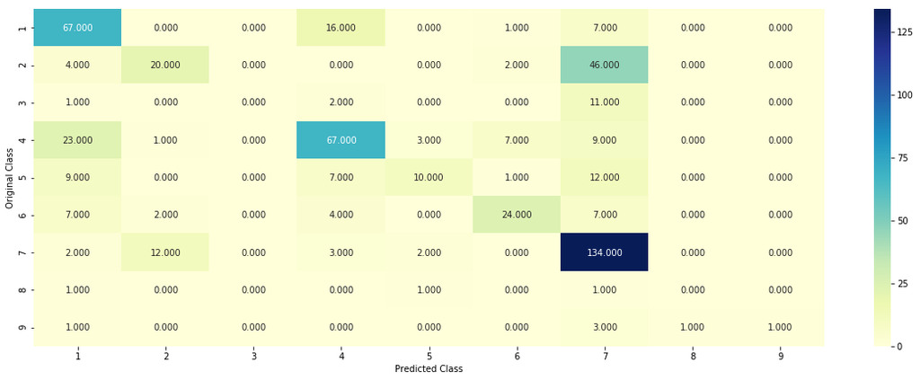

```
-------------------- Precision matrix (Columm Sum=1) --------------------
```

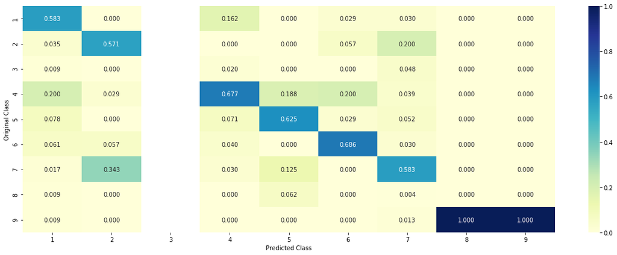

```
-------------------- Recall matrix (Row sum=1) --------------------
```

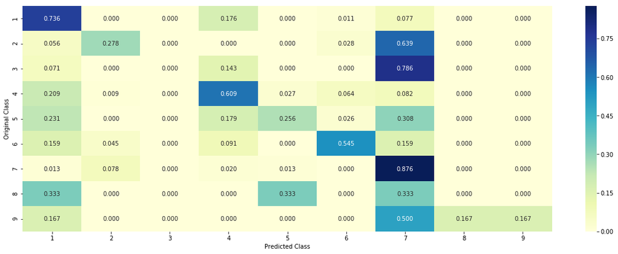

```python
clf = SGDClassifier(alpha = optimal_alpha, penalty='l2', loss='log', random_state=42)
clf.fit(train_x_onehotCoding, y_train)
sig_clf = CalibratedClassifierCV(clf, method="sigmoid")
sig_clf.fit(train_x_onehotCoding, y_train)
sig_clf_probs = sig_clf.predict_proba(cv_x_onehotCoding)
print("Log Loss :",log_loss(y_cv, sig_clf_probs))
print("Number of missclassified point :", np.count_nonzero((sig_clf.predict(cv_x_onehotCoding)- y_cv))/y_cv.shape[0])
plot_confusion_matrix(y_cv, sig_clf.predict(cv_x_onehotCoding.toarray()))
```

# Feature Engineering

```python
tfidf = TfidfVectorizer()
train_gene_feature_onehotCoding = tfidf.fit_transform(train_df['Gene'])
test_gene_feature_onehotCoding = tfidf.transform(test_df['Gene'])
cv_gene_feature_onehotCoding = tfidf.transform(cv_df['Gene'])


train_variation_feature_onehotCoding = tfidf.fit_transform(train_df['Variation'])
test_variation_feature_onehotCoding = tfidf.transform(test_df['Variation'])
cv_variation_feature_onehotCoding = tfidf.transform(cv_df['Variation'])
```

```python
tfidf = TfidfVectorizer(ngram_range = (1,4),max_features = 50000, min_df=3)
train_text_feature_onehotCoding = tfidf.fit_transform(train_df['TEXT'])
test_text_feature_onehotCoding = tfidf.transform(test_df['TEXT'])
cv_text_feature_onehotCoding = tfidf.transform(cv_df['TEXT'])

# Normalize the text feature vectors
# train_text_feature_onehotCoding = normalize(train_text_feature_onehotCoding, axis=0)
# test_text_feature_onehotCoding = normalize(test_text_feature_onehotCoding, axis=0)
# cv_text_feature_onehotCoding = normalize(cv_text_feature_onehotCoding, axis=0)
```

```python
train_gene_var_onehotCoding = hstack((train_gene_feature_onehotCoding,train_variation_feature_onehotCoding))
test_gene_var_onehotCoding = hstack((test_gene_feature_onehotCoding,test_variation_feature_onehotCoding))
cv_gene_var_onehotCoding = hstack((cv_gene_feature_onehotCoding,cv_variation_feature_onehotCoding))

# Final Train data
train_x_onehotCoding = hstack((train_gene_var_onehotCoding, train_text_feature_onehotCoding)).tocsr()
y_train = train_df['Class']

# Final Test data
test_x_onehotCoding = hstack((test_gene_var_onehotCoding, test_text_feature_onehotCoding)).tocsr()
y_test = test_df['Class']

# Final CV data
cv_x_onehotCoding = hstack((cv_gene_var_onehotCoding, cv_text_feature_onehotCoding)).tocsr()
y_cv = cv_df['Class']
```

```python
print(train_x_onehotCoding.shape, y_train.shape)
print(cv_x_onehotCoding.shape, y_cv.shape)
print(test_x_onehotCoding.shape, y_test.shape)
```

```
(2124, 52198) (2124,)
(532, 52198) (532,)
(665, 52198) (665,)
```

```
for alpha =  1e-06 The log loss is  1.205723093332427
for alpha =  1e-05 The log loss is  1.0671781492799948
for alpha =  0.0001 The log loss is  1.0304068761292855
for alpha =  0.001 The log loss is  1.0916224092080749
for alpha =  0.01 The log loss is  1.2491578124455045
for alpha =  0.1 The log loss is  1.424828973736361
for alpha =  1 The log loss is  1.499645609243859
for alpha =  10 The log loss is  1.5105588692500813
for alpha =  100 The log loss is  1.5118057888253564
```

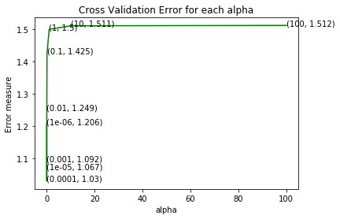

```
For the value alpha :  0.0001 The train log loss is  0.4018758954607178
For the value alpha :  0.0001 The CV log loss is  1.0304068761292855
For the value alpha :  0.0001 The test log loss is  0.9711204762016626
```

```python
# Train the model using Logistics Regression and Calibration model

alpha = [10**x for x in range(-6,3)]

cv_log_loss_values = []
for i in alpha:
    clf = SGDClassifier(class_weight = "balanced",alpha = i, loss = 'log', penalty = 'l2', random_state = 42)
    clf.fit(train_x_onehotCoding, y_train)
    sig_clf = CalibratedClassifierCV(clf, method = 'sigmoid')
    sig_clf.fit(train_x_onehotCoding, y_train)
    predict_y = sig_clf.predict_proba(cv_x_onehotCoding)
    cv_log_loss_values.append(log_loss(y_cv, predict_y,labels=clf.classes_, eps=1e-15))
    print("for alpha = ", i, "The log loss is ", log_loss(y_cv, predict_y,labels=clf.classes_, eps=1e-15))

plt.plot(alpha, cv_log_loss_values, c = 'g')
for i, txt in enumerate(np.round(cv_log_loss_values,3)):
    plt.annotate((alpha[i],txt),(alpha[i],cv_log_loss_values[i]))

plt.title('Cross Validation Error for each alpha')
plt.xlabel('alpha')
plt.ylabel('Error measure')
plt.show()

optimal_alpha = alpha[np.argmin(cv_log_loss_values)]

clf = SGDClassifier(class_weight = "balanced",alpha = optimal_alpha, loss = 'log', penalty = 'l2', random_state = 42)
clf.fit(train_x_onehotCoding, y_train)
sig_clf = CalibratedClassifierCV(clf, method = 'sigmoid')
sig_clf.fit(train_x_onehotCoding, y_train)

predict_y = sig_clf.predict_proba(train_x_onehotCoding)
print("For the value alpha : ", optimal_alpha, "The train log loss is ", log_loss(y_train, predict_y))
predict_y = sig_clf.predict_proba(cv_x_onehotCoding)
print("For the value alpha : ", optimal_alpha, "The CV log loss is ",log_loss(y_cv, predict_y))
predict_y = sig_clf.predict_proba(test_x_onehotCoding)
print("For the value alpha : ", optimal_alpha, "The test log loss is ", log_loss(y_test, predict_y))
```

```
Number of missclassified point : 0.37593984962406013
-------------------- Confusion matrix --------------------
```

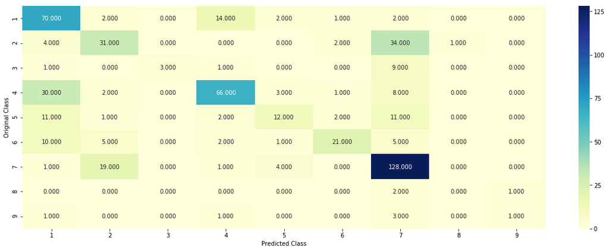

```
-------------------- Precision matrix (Columm Sum=1) --------------------
```

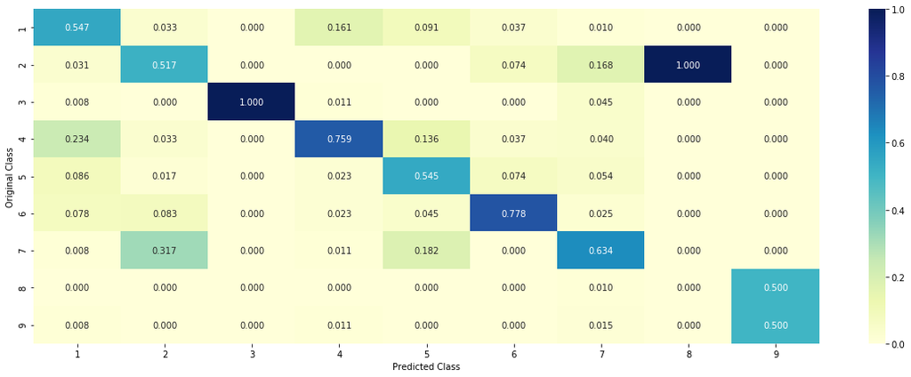

```
-------------------- Recall matrix (Row sum=1) --------------------
```

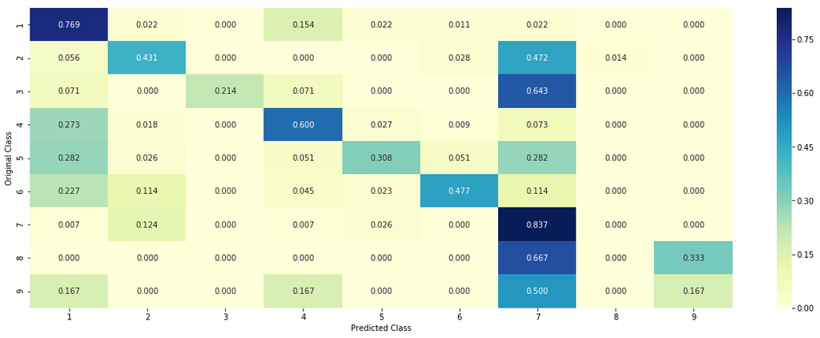

```python
# Test the model on test data

clf = SGDClassifier(alpha = optimal_alpha, loss = 'log', penalty = 'l2', random_state = 42)
clf.fit(train_x_onehotCoding, y_train)
sig_clf = CalibratedClassifierCV(clf, method = 'sigmoid')
sig_clf.fit(train_x_onehotCoding, y_train)
predict_y = sig_clf.predict_proba(test_x_onehotCoding)
print("Number of missclassified point :", np.count_nonzero((sig_clf.predict(cv_x_onehotCoding)- y_cv))/y_cv.shape[0])
plot_confusion_matrix(y_cv, sig_clf.predict(cv_x_onehotCoding.toarray()))
```

# 2nd Hack

```python
# Ref : https://medium.com/@tulasiram11729/personalized-cancer-diagnosis-3d6f09a6b8c9
# one-hot encoding of Gene feature.
gene_vectorizer = TfidfVectorizer()
train_gene_feature_onehotCoding = gene_vectorizer.fit_transform(train_df['Gene'])
test_gene_feature_onehotCoding = gene_vectorizer.transform(test_df['Gene'])
cv_gene_feature_onehotCoding = gene_vectorizer.transform(cv_df['Gene'])
```

```python
# one-hot encoding of Variation feature.
var_vectorizer = TfidfVectorizer()
train_variation_feature_onehotCoding = var_vectorizer.fit_transform(train_df['Variation'])
test_variation_feature_onehotCoding = var_vectorizer.transform(test_df['Variation'])
cv_variation_feature_onehotCoding = var_vectorizer.transform(cv_df['Variation'])
```

```python
tfidf = TfidfVectorizer()
train_text_feature_onehotCoding = tfidf.fit_transform(train_df['TEXT'])
test_text_feature_onehotCoding = tfidf.transform(test_df['TEXT'])
cv_text_feature_onehotCoding = tfidf.transform(cv_df['TEXT'])
```

```python
list = []
for word in result['Gene'].values:
    list.append(word)
for word in result['Variation'].values:
    list.append(word)
```

```python
tfidf = TfidfVectorizer(ngram_range = (1,4),max_features = 25000, min_df=3)
list_vect = tfidf.fit_transform(list)
gene_variation_features = tfidf.get_feature_names()

train_text = tfidf.transform(train_df['TEXT'])
test_text = tfidf.transform(test_df['TEXT'])
cv_text = tfidf.transform(cv_df['TEXT'])
```

```python
train_gene_var_onehotCoding = hstack((train_gene_feature_onehotCoding,train_variation_feature_onehotCoding))
test_gene_var_onehotCoding = hstack((test_gene_feature_onehotCoding,test_variation_feature_onehotCoding))
cv_gene_var_onehotCoding = hstack((cv_gene_feature_onehotCoding,cv_variation_feature_onehotCoding))

# Final Train data
train_x_onehotCoding = hstack((train_gene_var_onehotCoding, train_text, train_text_feature_onehotCoding)).tocsr()
y_train = train_df['Class']

# Final Test data
test_x_onehotCoding = hstack((test_gene_var_onehotCoding, test_text, test_text_feature_onehotCoding)).tocsr()
y_test = test_df['Class']

# Final CV data
cv_x_onehotCoding = hstack((cv_gene_var_onehotCoding, cv_text, cv_text_feature_onehotCoding)).tocsr()
y_cv = cv_df['Class']
```

```python
print(train_x_onehotCoding.shape, y_train.shape)
print(cv_x_onehotCoding.shape, y_cv.shape)
print(test_x_onehotCoding.shape, y_test.shape)
```

```
(2124, 124376) (2124,)
(532, 124376) (532,)
(665, 124376) (665,)
```

```
for alpha =  1e-06 The log loss is  1.1686493426592406
for alpha =  1e-05 The log loss is  1.0920477872710876
for alpha =  0.0001 The log loss is  1.0474041234306193
for alpha =  0.001 The log loss is  1.1024583966400152
for alpha =  0.01 The log loss is  1.2639668458454714
for alpha =  0.1 The log loss is  1.470227252242387
for alpha =  1 The log loss is  1.562774566582957
for alpha =  10 The log loss is  1.5767741582525021
```

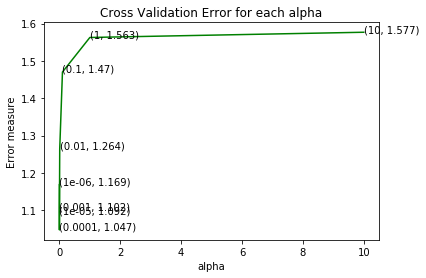

```
For the value alpha :  0.0001 The train log loss is  0.42118857766786044
For the value alpha :  0.0001 The CV log loss is  1.0474041234306193
For the value alpha :  0.0001 The test log loss is  0.9976629257025263
```

```python
# Train the model using Logistics Regression and Calibration model

alpha = [10**x for x in range(-6,2)]

cv_log_loss_values = []
for i in alpha:
    clf = SGDClassifier(class_weight = "balanced",alpha = i, loss = 'log', penalty = 'l2', random_state = 42)
    clf.fit(train_x_onehotCoding, y_train)
    sig_clf = CalibratedClassifierCV(clf, method = 'sigmoid')
    sig_clf.fit(train_x_onehotCoding, y_train)
    predict_y = sig_clf.predict_proba(cv_x_onehotCoding)
    cv_log_loss_values.append(log_loss(y_cv, predict_y,labels=clf.classes_, eps=1e-15))
    print("for alpha = ", i, "The log loss is ", log_loss(y_cv, predict_y,labels=clf.classes_, eps=1e-15))

plt.plot(alpha, cv_log_loss_values, c = 'g')
for i, txt in enumerate(np.round(cv_log_loss_values,3)):
    plt.annotate((alpha[i],txt),(alpha[i],cv_log_loss_values[i]))

plt.title('Cross Validation Error for each alpha')
plt.xlabel('alpha')
plt.ylabel('Error measure')
plt.show()

optimal_alpha = alpha[np.argmin(cv_log_loss_values)]

clf = SGDClassifier(class_weight = "balanced",alpha = optimal_alpha, loss = 'log', penalty = 'l2', random_state = 42)
clf.fit(train_x_onehotCoding, y_train)
sig_clf = CalibratedClassifierCV(clf, method = 'sigmoid')
sig_clf.fit(train_x_onehotCoding, y_train)

predict_y = sig_clf.predict_proba(train_x_onehotCoding)
print("For the value alpha : ", optimal_alpha, "The train log loss is ", log_loss(y_train, predict_y))
predict_y = sig_clf.predict_proba(cv_x_onehotCoding)
print("For the value alpha : ", optimal_alpha, "The CV log loss is ",log_loss(y_cv, predict_y))
predict_y = sig_clf.predict_proba(test_x_onehotCoding)
print("For the value alpha : ", optimal_alpha, "The test log loss is ", log_loss(y_test, predict_y))
```

```
Number of missclassified point : 0.36654135338345867
-------------------- Confusion matrix --------------------
```

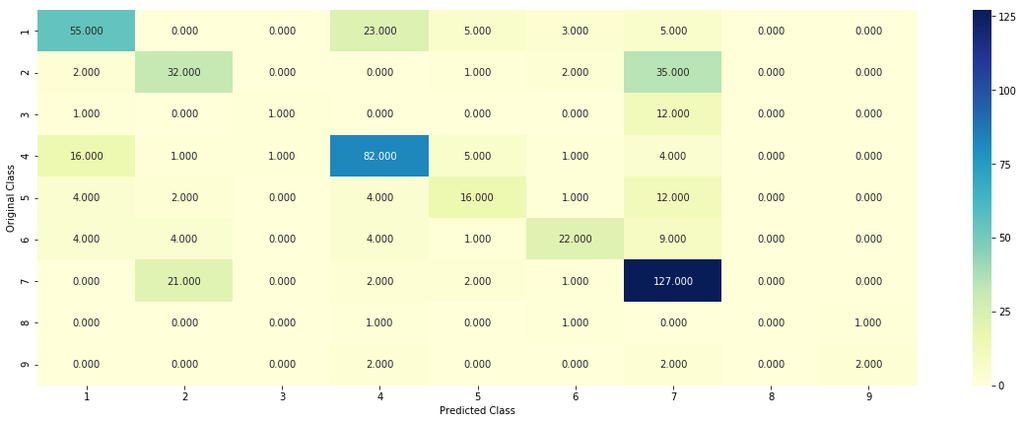

```
-------------------- Precision matrix (Columm Sum=1) --------------------
```

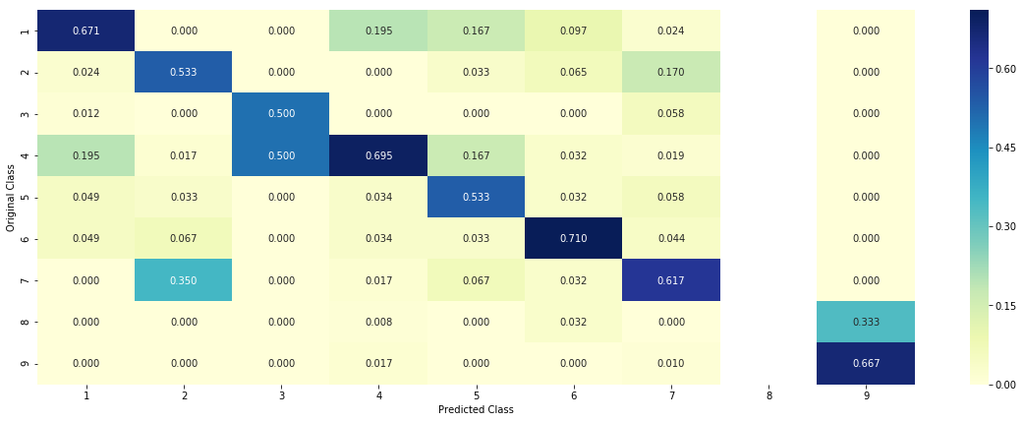

```
-------------------- Recall matrix (Row sum=1) --------------------
```

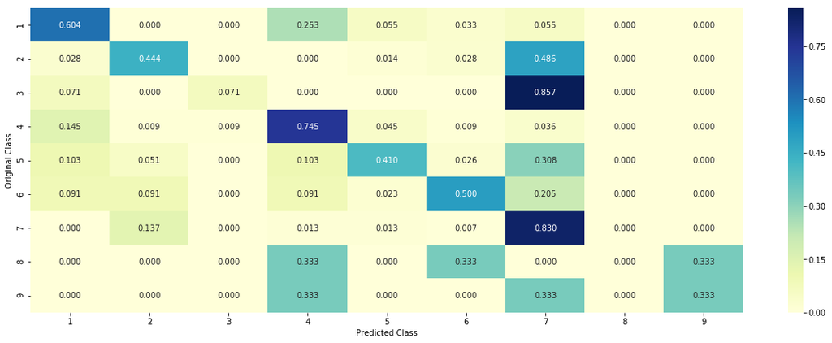

```python
# Test the model on test data

clf = SGDClassifier(alpha = optimal_alpha, loss = 'log', penalty = 'l2', random_state = 42)
clf.fit(train_x_onehotCoding, y_train)
sig_clf = CalibratedClassifierCV(clf, method = 'sigmoid')
sig_clf.fit(train_x_onehotCoding, y_train)
predict_y = sig_clf.predict_proba(test_x_onehotCoding)
print("Number of missclassified point :", np.count_nonzero((sig_clf.predict(cv_x_onehotCoding)- y_cv))/y_cv.shape[0])
plot_confusion_matrix(y_cv, sig_clf.predict(cv_x_onehotCoding.toarray()))
```

# Complete process

1. Initially, we have 2 csv files, one having ID, Gene, Variation and Class. Other having ID and TEXT.
2. After converting into dataframes, the 2 dataframes are joined on ID.
3. The features are Gene, Variation and TEXT. Label is Class which is a multi-class classification(1-9)
4. Next, Text feature is preprocessed and Null values in Text are filled with Gene and Variation values.
5. Then the Data is split into train, test and CV
6. The features of string are converted into numerical vectors using two ways. One hot Encoding(BOW or tfidf) and Response coding(Mean Vlaue Replacement). These are selected based on the model
7. Univariate Analysis is done using any model to find the stability of each feature.
8. Then the three features are stacked horizontally to form the final features.
9. Applied the above models on the given features and found the log loss for each model.

## Results

```python
from prettytable import PrettyTable

x = PrettyTable()

x.field_names = ["S.No", "Model", "Train", "CV", "Test", "% of Misclassification points"]

x.add_row([1, "Naive Bayes",0.724, 1.275, 1.216, 41.9])
x.add_row([2, "KNN",0.731, 1.11, 1.117,38.9])
x.add_row([3, "Logistic Regression with class Balancing",0.551, 1.037, 1.047,35.52])
x.add_row([4, "Logistic Regression without class Balancing",0.540, 1.083, 1.068, 35.15])
x.add_row([5, "Linear SVM",0.774, 1.150, 1.154, 36.84])
x.add_row([6, "Random Forest Classifier with One hot Encoding",0.837, 1.253, 1.228, 47.74])
x.add_row([7, "Random Forest Classifier with Response Coding",0.058, 1.348, 1.314, 43.79])
x.add_row([8, "Stacking Model: LR+NB+SVM",0.789, 1.223, 1.189, 40.6])
x.add_row([8, "Majority Voting Classifier",0.928, 1.262, 1.218, 40.9])
x.add_row([9, "Logistic Regression with Count Vectorizer including Unigrams and Bigrams",1.081, 1.380, 1.346,39.28])
x.add_row([10, "Feature Engineering 1",0.401, 1.030, 0.971,37.59])
x.add_row([11, "Feature Engineering 2",0.421, 1.047, 0.997,36.65])

print(x)
```

```
+------+--------------------------------------------------------------------------+-------+-------+-------+-------------------------------+
| S.No |                                  Model                                   | Train |   CV  |  Test | % of Misclassification points |
+------+--------------------------------------------------------------------------+-------+-------+-------+-------------------------------+
|  1   |                               Naive Bayes                                | 0.724 | 1.275 | 1.216 |              41.9             |
|  2   |                                   KNN                                    | 0.731 |  1.11 | 1.117 |              38.9             |
|  3   |                 Logistic Regression with class Balancing                 | 0.551 | 1.037 | 1.047 |             35.52             |
|  4   |               Logistic Regression without class Balancing                |  0.54 | 1.083 | 1.068 |             35.15             |
|  5   |                                Linear SVM                                | 0.774 |  1.15 | 1.154 |             36.84             |
|  6   |              Random Forest Classifier with One hot Encoding              | 0.837 | 1.253 | 1.228 |             47.74             |
|  7   |              Random Forest Classifier with Response Coding               | 0.058 | 1.348 | 1.314 |             43.79             |
|  8   |                        Stacking Model: LR+NB+SVM                         | 0.789 | 1.223 | 1.189 |              40.6             |
|  8   |                        Majority Voting Classifier                        | 0.928 | 1.262 | 1.218 |              40.9             |
|  9   | Logistic Regression with Count Vectorizer including Unigrams and Bigrams | 1.081 |  1.38 | 1.346 |             39.28             |
|  10  |                          Feature Engineering 1                           | 0.401 |  1.03 | 0.971 |             37.59             |
|  11  |                          Feature Engineering 2                           | 0.421 | 1.047 | 0.997 |             36.65             |
+------+--------------------------------------------------------------------------+-------+-------+-------+-------------------------------+
```

# Final Conclusion

1. Logistic Regression has performed well compared to other models and Random Forest has performed very poor.
2. Logistic Regression with Count Vectorizer including unigrams and bigrams has given log loss of 1.346. So we can say that tfidf Vectorizer is better than Count Vectorizer for this model.
3. After applying Feature Engineering with Tfidf including 4grams, the log loss is decreased to 0.971 which is very good value.
4. When I consider the Gene and Variants Feature values to transform the Text feature values using Tfidf, the log loss is decreased to 0.997 which is also a good one.
5. We can still reduce the log loss by changing the tfidf Vectorizer parameters but we can't see much difference from the present value.
6. So, to reduce the log loss further domain knowledge is needed where we can add more features.